# **【Pathological Slide Review】**

Yi-Hsin Lu

## **Abstract**

This report investigates the impact of high collinearity among variables on the predictability of survival models. Collinearity can lead to unreliable model coefficients. To address this challenge, we employ Principal Component Analysis (PCA), Least Absolute Shrinkage and Selection Operator (LASSO), and Akaike Information Criterion (AIC) to identify the optimal variable combination for building robust survival models.

Our analysis reveals that the first three principal components explain approximately 90% variations, with “pT stage” emerging as the most significant component. Furthermore, both LASSO regression and stepwise selection based on AIC consistently select “pT stage,” “PNI”, and “Surgical margin” as the most relevant variables for survival prediction.

Based on these findings, we recommend using “pT stage,” “PNI,” and “Surgical margin” as the core set of variables for constructing survival models, including Overall Survival, Cancer-Specific Survival, and Disease-Free Survival models.

## **1 Variables (drop `NA`)**

$\text{Table}\:\text{2.}$ Summary for Variables ($N:377\Rightarrow341$)

[output not shown]

### **1.1 Data Table** ( $\mathcal{X}:$ variables)

```r
pSlide_revX
```

|  | Grade | Configuration | Invasiveness | pT_stage | LVI | PNI | Surgical_margin | UC |
| --- | --- | --- | --- | --- | --- | --- | --- | --- |
| 1 | 2 | 2 | 1 | 2 | 0 | 0 | 0 | 1 |
| 2 | 2 | 1 | 1 | 3 | 0 | 0 | 0 | 0 |
| 3 | 2 | 1 | 1 | 3 | 0 | 0 | 0 | 0 |
| 4 | 1 | 1 | 0 | 1 | 0 | 0 | 0 | 0 |
| 5 | 2 | 2 | 1 | 4 | 1 | 0 | 1 | 1 |
| 6 | 2 | 3 | 1 | 4 | 0 | 0 | 0 | 1 |
| 7 | 2 | 1 | 0 | 1 | 0 | 0 | 0 | 0 |
| 8 | 2 | 1 | 0 | 1 | 0 | 0 | 0 | 0 |
| 9 | 2 | 1 | 0 | 1 | 0 | 0 | 0 | 0 |
| 10 | 2 | 3 | 1 | 5 | 1 | 0 | 0 | 0 |

[output cut: 331 more lines]

### **1.2 Data Table** ( $\mathcal{Y}:$ results)

```r
pSlide_revY
```

|  | RE_Mor | RE_CS | RE_DiF | RE_BF | Followupyear | Followupyear_DF | Followupyear_BF |
| --- | --- | --- | --- | --- | --- | --- | --- |
| 1 | 0 | 0 | 0 | 0 | 7.12 | 3.99 | 3.99 |
| 2 | 0 | 0 | 0 | 1 | 6.29 | 4.85 | 0.29 |
| 3 | 1 | 0 | 0 | 1 | 1.77 | 1.77 | 0.42 |
| 4 | 1 | 0 | 1 | 0 | 2.72 | 2.70 | 2.72 |
| 5 | 1 | 1 | 1 | 0 | 2.70 | 1.71 | 2.69 |
| 6 | 0 | 0 | 0 | 0 | 4.34 | 4.34 | 4.34 |
| 7 | 1 | 0 | 1 | 1 | 2.58 | 0.50 | 0.27 |
| 8 | 1 | 0 | 0 | 0 | 4.51 | 4.50 | 4.50 |
| 9 | 1 | 0 | 0 | 1 | 3.15 | 3.15 | 0.82 |
| 10 | 0 | 0 | 0 | 0 | 4.88 | 4.88 | 4.88 |

[output cut: 331 more lines]

## **2 PCA for variables**

### PC1-PC2

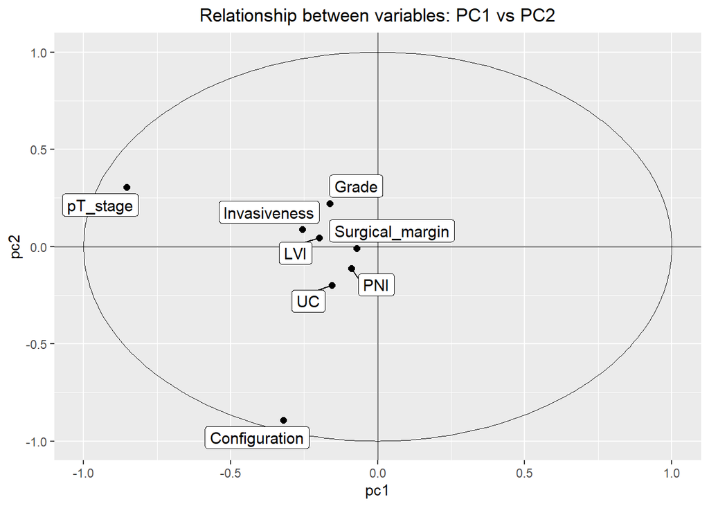

|  | pc1 | pc2 | pc3 |
| --- | --- | --- | --- |
| Grade | -0.16312170 | 0.222036242 | -0.39158608 |
| Configuration | -0.32048140 | -0.892105032 | -0.24903311 |
| Invasiveness | -0.25672156 | 0.087619202 | -0.22144068 |
| pT_stage | -0.85305248 | 0.304308645 | -0.04068171 |
| LVI | -0.19945596 | 0.046260673 | 0.56937730 |
| PNI | -0.08986858 | -0.111128863 | 0.21060538 |
| Surgical_margin | -0.07138607 | -0.008012735 | 0.30928814 |
| UC | -0.15531735 | -0.200034411 | 0.51937230 |

### PC2-PC3

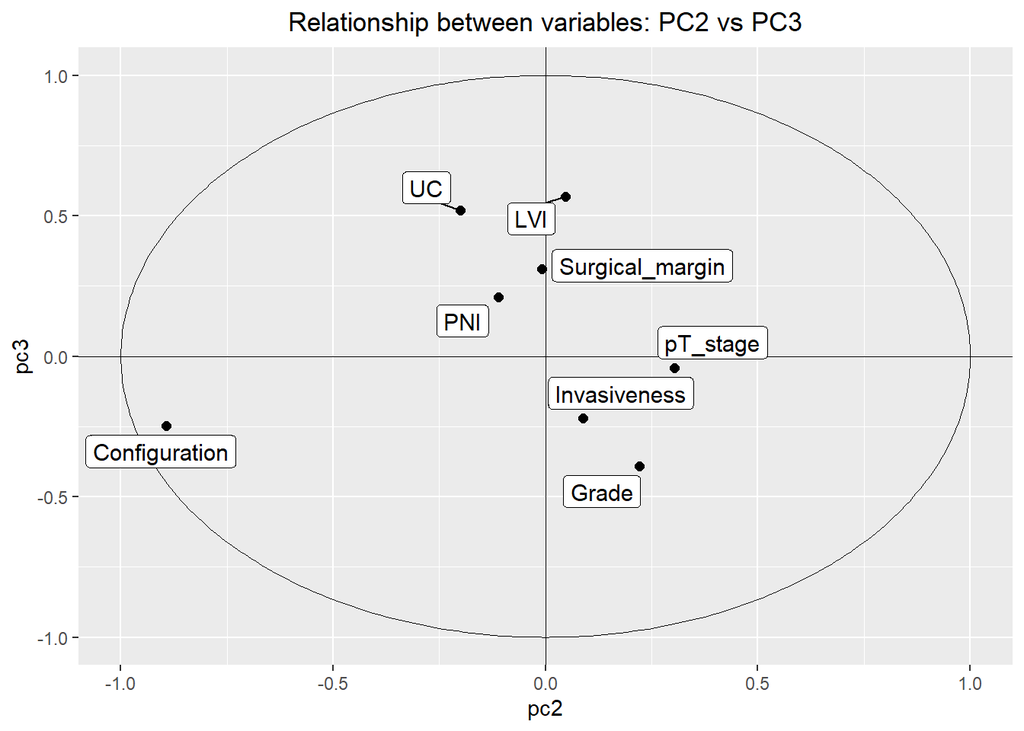

### PC1-PC3

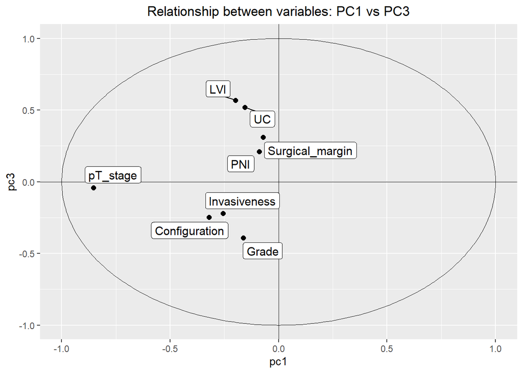

### Explained Variation of PCA

- PC1, PC2, and PC3 explain $88.2\%$ Proportion of Variance, and PC1 explains $75.2\%$.
- The PC1-PC2 plot explains $84.4\%$ of the variance, indicating a strong representation of the real data.

```
## Importance of components:
##                           PC1     PC2    PC3     PC4     PC5     PC6     PC7
## Standard deviation     1.6901 0.59314 0.3800 0.35640 0.33241 0.29837 0.25526
## Proportion of Variance 0.7518 0.09259 0.0380 0.03343 0.02908 0.02343 0.01715
## Cumulative Proportion  0.7518 0.84437 0.8824 0.91579 0.94487 0.96830 0.98545
##                            PC8
## Standard deviation     0.23511
## Proportion of Variance 0.01455
## Cumulative Proportion  1.00000
```

## **3 LASSO** (variable selection)

### OS

```r
lasso.os
```

```
## 8 x 1 sparse Matrix of class "dgCMatrix"
##                        s0
## Grade           .
## Configuration   .
## Invasiveness    .
## pT_stage        0.1798452
## LVI             0.2838351
## PNI             0.6312499
## Surgical_margin 0.3800193
## UC              .
```

### CS

```r
lasso.cs
```

```
## 8 x 1 sparse Matrix of class "dgCMatrix"
##                         s0
## Grade           .
## Configuration   .
## Invasiveness    .
## pT_stage        0.33373593
## LVI             0.51987898
## PNI             0.75149830
## Surgical_margin 0.55961476
## UC              0.01639912
```

### DFS

```r
lasso.dfs
```

```
## 8 x 1 sparse Matrix of class "dgCMatrix"
##                        s0
## Grade           .
## Configuration   .
## Invasiveness    0.0944480
## pT_stage        0.1117814
## LVI             0.4029921
## PNI             0.3583027
## Surgical_margin 0.5557731
## UC              .
```

### BRFS

```r
lasso.brfs
```

```
## 8 x 1 sparse Matrix of class "dgCMatrix"
##                 s0
## Grade            0
## Configuration    .
## Invasiveness     .
## pT_stage         .
## LVI              .
## PNI              .
## Surgical_margin  .
## UC               .
```

### Survival Curve

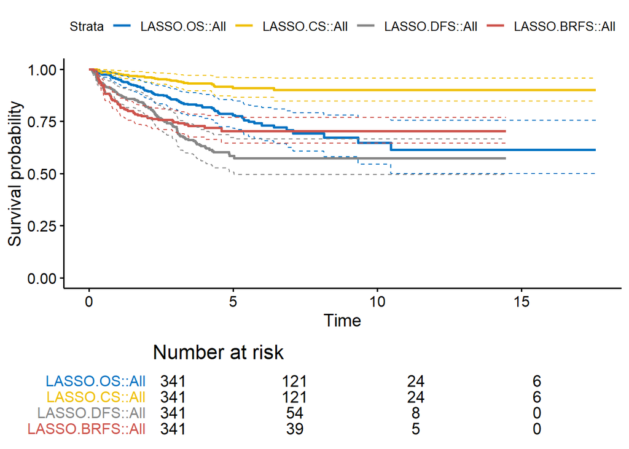

## **4 AIC** (model selection)

**Selected Variables:**

- Extent
- PNI
- Margins

### OS

```r
summary(AIC.os)
```

```
## Call:
## coxph(formula = Surv(Followupyear, RE_Mor) ~ pT_stage + PNI +
##     Surgical_margin, data = df_suv.os, x = TRUE, y = TRUE)
##
##   n= 341, number of events= 95
##
##                    coef exp(coef) se(coef)     z Pr(>|z|)
## pT_stage        0.27483   1.31631  0.08539 3.219  0.00129 **
## PNI             0.77524   2.17112  0.27786 2.790  0.00527 **
## Surgical_margin 0.54538   1.72527  0.26657 2.046  0.04076 *
## ---
## Signif. codes:  0 '***' 0.001 '**' 0.01 '*' 0.05 '.' 0.1 ' ' 1
##
##                 exp(coef) exp(-coef) lower .95 upper .95
## pT_stage            1.316     0.7597     1.113     1.556
## PNI                 2.171     0.4606     1.259     3.743
## Surgical_margin     1.725     0.5796     1.023     2.909
##
## Concordance= 0.688  (se = 0.029 )
## Likelihood ratio test= 44.44  on 3 df,   p=1e-09
## Wald test            = 50.53  on 3 df,   p=6e-11
## Score (logrank) test = 60.36  on 3 df,   p=5e-13
```

### CS

```r
summary(AIC.cs)
```

```
## Call:
## coxph(formula = Surv(Followupyear, RE_CS) ~ pT_stage + PNI +
##     Surgical_margin, data = df_suv.cs, x = TRUE, y = TRUE)
##
##   n= 341, number of events= 46
##
##                   coef exp(coef) se(coef)     z Pr(>|z|)
## pT_stage        0.5250    1.6905   0.1397 3.757 0.000172 ***
## PNI             0.9100    2.4842   0.3475 2.619 0.008823 **
## Surgical_margin 0.6975    2.0088   0.3242 2.152 0.031425 *
## ---
## Signif. codes:  0 '***' 0.001 '**' 0.01 '*' 0.05 '.' 0.1 ' ' 1
##
##                 exp(coef) exp(-coef) lower .95 upper .95
## pT_stage            1.691     0.5915     1.285     2.223
## PNI                 2.484     0.4025     1.257     4.909
## Surgical_margin     2.009     0.4978     1.064     3.792
##
## Concordance= 0.781  (se = 0.036 )
## Likelihood ratio test= 53.33  on 3 df,   p=2e-11
## Wald test            = 51.69  on 3 df,   p=3e-11
## Score (logrank) test = 75.87  on 3 df,   p=2e-16
```

### DFS

```r
summary(AIC.dfs)
```

```
## Call:
## coxph(formula = Surv(Followupyear_DF, RE_DiF) ~ pT_stage + LVI +
##     PNI + Surgical_margin, data = df_suv.dfs, x = TRUE, y = TRUE)
##
##   n= 341, number of events= 134
##
##                    coef exp(coef) se(coef)     z Pr(>|z|)
## pT_stage        0.16934   1.18452  0.08617 1.965  0.04939 *
## LVI             0.44108   1.55439  0.25630 1.721  0.08526 .
## PNI             0.44645   1.56276  0.25189 1.772  0.07632 .
## Surgical_margin 0.66446   1.94343  0.21260 3.125  0.00178 **
## ---
## Signif. codes:  0 '***' 0.001 '**' 0.01 '*' 0.05 '.' 0.1 ' ' 1
##
##                 exp(coef) exp(-coef) lower .95 upper .95
## pT_stage            1.185     0.8442    1.0005     1.402
## LVI                 1.554     0.6433    0.9406     2.569
## PNI                 1.563     0.6399    0.9539     2.560
## Surgical_margin     1.943     0.5146    1.2812     2.948
##
## Concordance= 0.674  (se = 0.025 )
## Likelihood ratio test= 54.07  on 4 df,   p=5e-11
## Wald test            = 61.75  on 4 df,   p=1e-12
## Score (logrank) test = 71.99  on 4 df,   p=9e-15
```

### BRFS

```r
summary(AIC.brfs)
```

```
## Call:
## coxph(formula = Surv(Followupyear_BF, RE_BF) ~ Configuration,
##     data = df_suv.brfs, x = TRUE, y = TRUE)
##
##   n= 341, number of events= 80
##
##                  coef exp(coef) se(coef)      z Pr(>|z|)
## Configuration -0.2514    0.7777   0.1645 -1.529    0.126
##
##               exp(coef) exp(-coef) lower .95 upper .95
## Configuration    0.7777      1.286    0.5634     1.073
##
## Concordance= 0.56  (se = 0.026 )
## Likelihood ratio test= 2.55  on 1 df,   p=0.1
## Wald test            = 2.34  on 1 df,   p=0.1
## Score (logrank) test = 2.37  on 1 df,   p=0.1
```

### Survival Curve

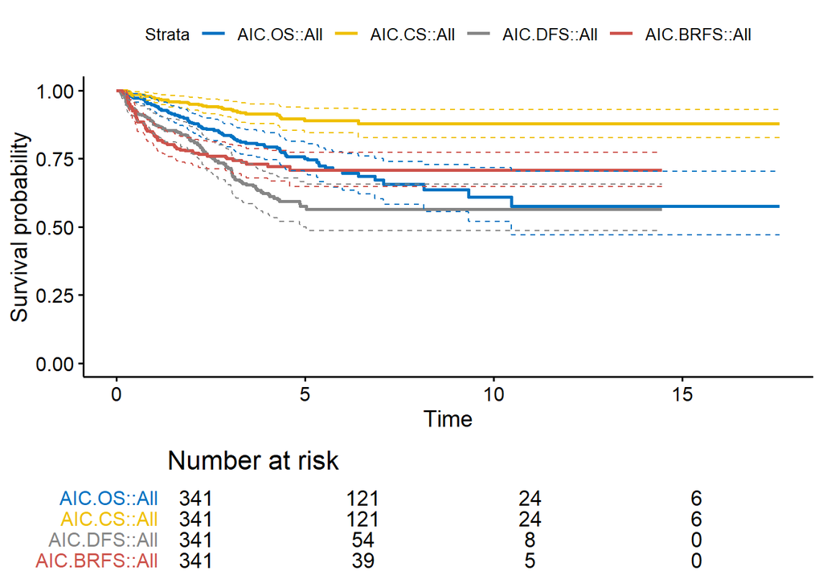

## **5 Comparison**

Variables for original model: $\text{pT stage}$ and $\text{Surgical margin}$.

### OS

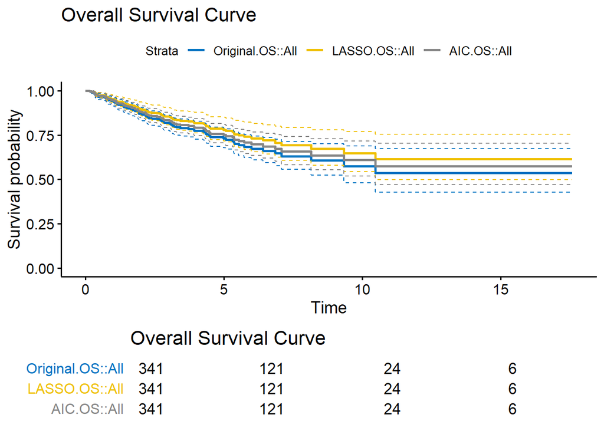

### CS

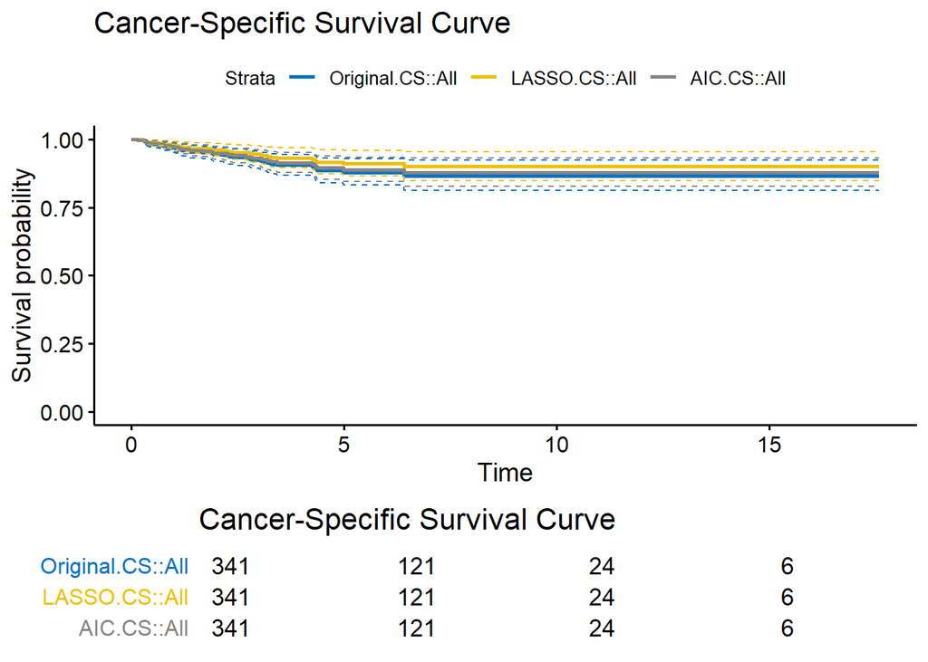

### DFS

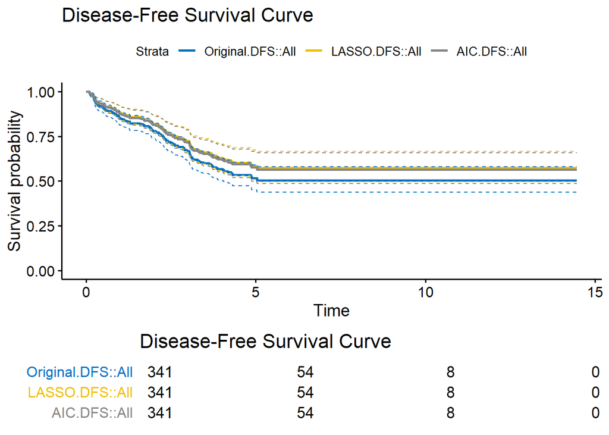

### BRFS

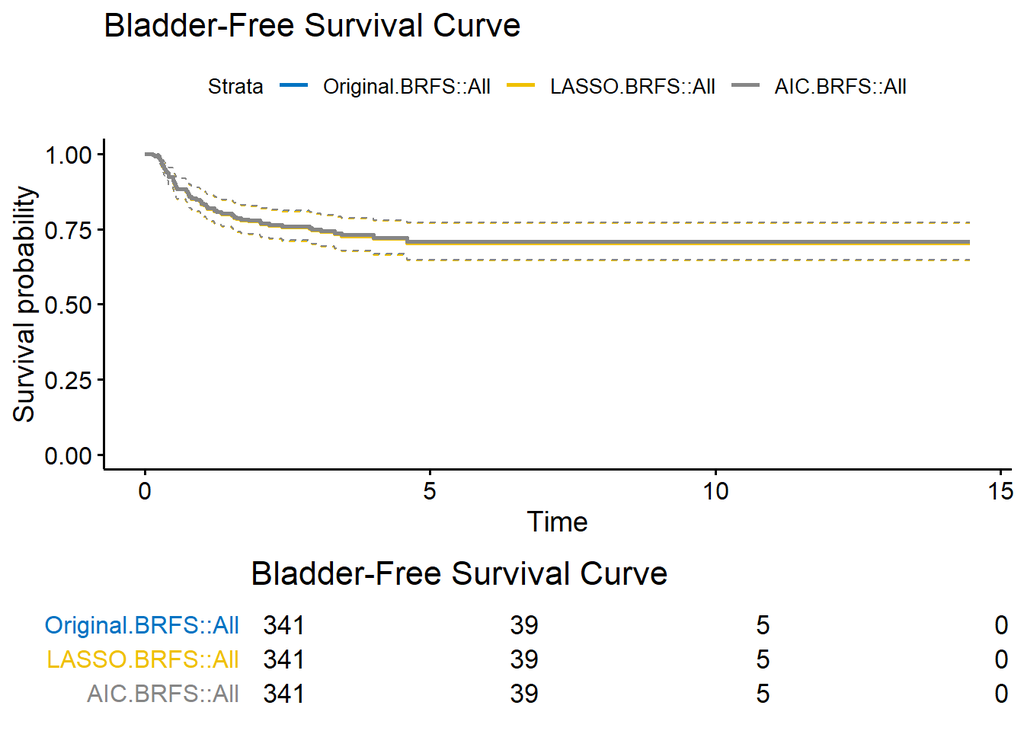

## **6 Performance Matrices**

### C-index

|  | ORG | LASSO | AIC |
| --- | --- | --- | --- |
| OS | 0.6780469 | 0.6859721 | 0.6883003 |
| CS | 0.7654054 | 0.7842827 | 0.7810395 |
| DFS | 0.6618231 | 0.6747104 | 0.6743361 |
| BRFS | 0.5287867 | 0.5127614 | 0.5598312 |

### Calibration Curve

#### OS

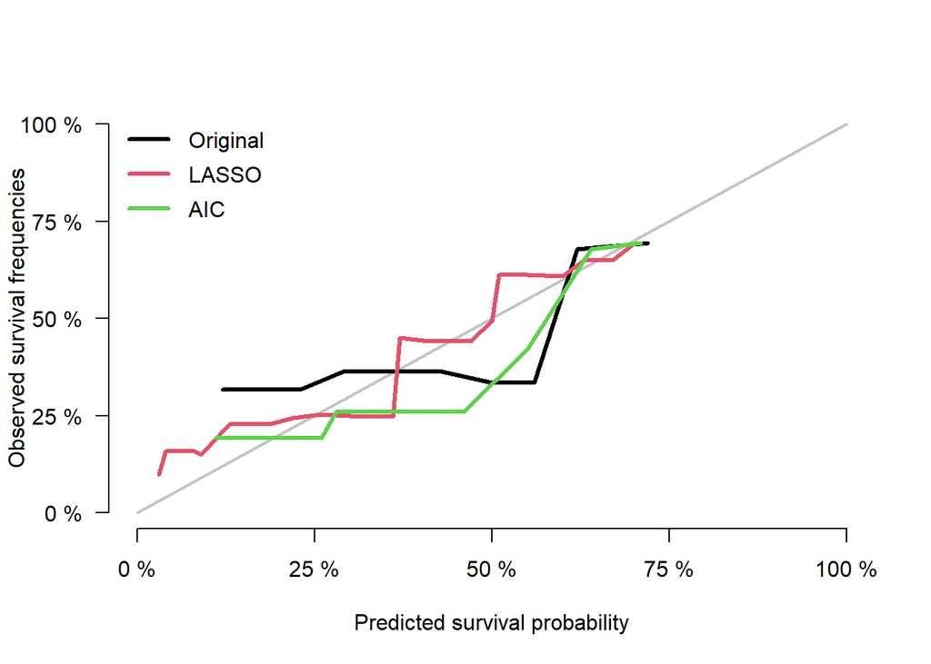

#### CS

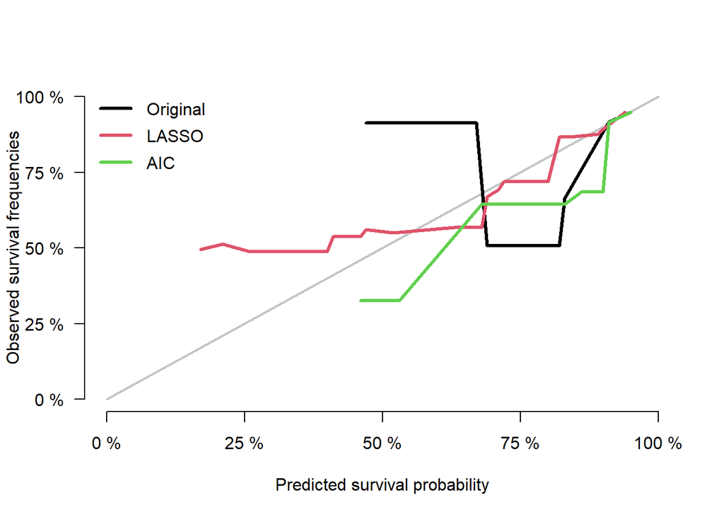

#### DFS

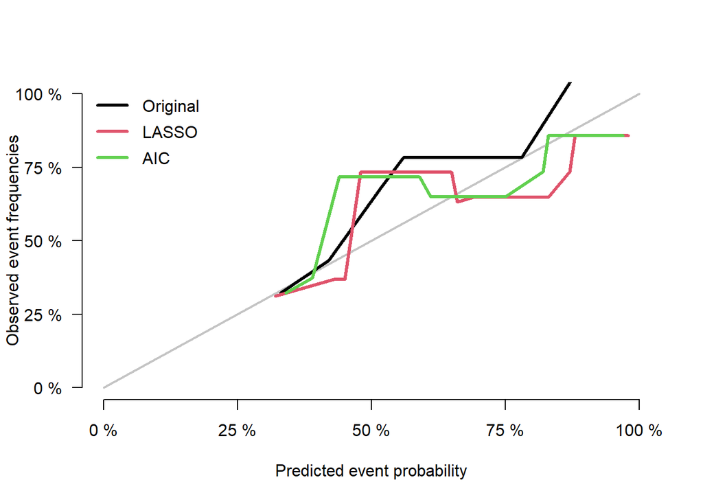

#### BRFS

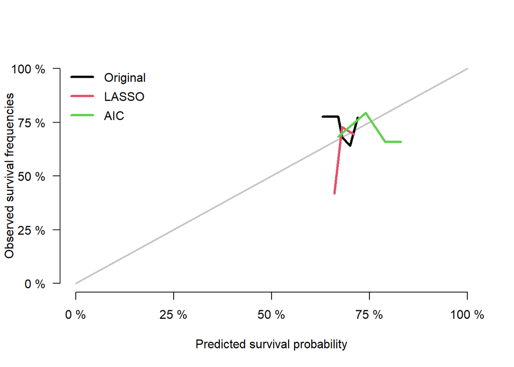

## **7 Conclusion**

- For the survival model, we utilize **`PCA`**, **`LASSO`**, and **`AIC`** to select the variables. (see **Remark**)
- PCA map display the most of variables are lying on the x-axis and y-axis, it means they are from the same direction.
- Results of **`LASSO`** and **`AIC`** (see $\text{Table}\:\text{1}$)

$\text{Table}\:\text{1.}$Variables Selection for Models and Methods

[output not shown]

- Clearly, **Grade** is dropped.
- **pT stage**, **PNI**, and **Surgical margin** are selected from the methods because, except for the “BRFS” model, these variables are effective for the model.
- In the “BRFS” model, `AIC` only selects **Configuration**, and `LASSO` drops all variables. Even if we add **pT stage**, **LVI**, **PNI**, and **Surgical margin** into the model, these methods still drop them all.

#### **Remark**

- PCA (Principal Component Analysis), a dimensionality reduction technique, is used to examine the relationships between variables.
- LASSO (Least Absolute Shrinkage and Selection Operator), a regression method, is used for variable/feature selection.
- AIC (Akaike Information Criterion), a measure of model quality, is used for model selection.